# Using mixedSSA

Smith Freeman

2025-05-13

```r
library(glmmTMB)
library(mixedSSA)
library(here)
library(stringr)
library(ggpubr)
```

## Fitting Integrated Step-Selection Analyses

Here we fit two ISSAs using `glmmTMB` the fisher movement data available in the package. Models 1 and 2 have movement kernels that depend on a categorical variable (i.e., elevation factor - low, medium, and high) and a continuous variable (i.e., elevation - in meters), respectively.

We include a helper function here for fitting the models using `glmmTMB`:

```r
# Model fitting function
fit_model <- function(data, model_name, interaction_var_name,
                      habitat_selection_var_name, include_random_effects,
                      save_model = TRUE,
                      from_cache = FALSE) {
  # If you've already fit the model once, just pull it from the cache
  file_path <- here(paste0(model_name, ".rds"))

  if (from_cache) {
    model <- readRDS(file_path)
    return(model)
  }


  if (include_random_effects) {
    # Model parameterization, including random effects for the movement parameters
    formula <- as.formula(str_interp("case_ ~ sl_ + log_sl_ + cos(ta_) +
  ${habitat_selection_var_name} +
  ${interaction_var_name}:sl_ + ${interaction_var_name}:log_sl_ +
  ${interaction_var_name}:cos(ta_) +
  (1 | step_id_) + (0 + sl_ + log_sl_ + cos(ta_) | id)"))
  } else {
    formula <- as.formula(str_interp("case_ ~ sl_ + log_sl_ + cos(ta_) +
  ${habitat_selection_var_name} +
  ${interaction_var_name}:sl_ + ${interaction_var_name}:log_sl_ +
  ${interaction_var_name}:cos(ta_) +
  (1 | step_id_)"))
  }



  model_config <- glmmTMB(
    formula,
    REML = TRUE,
    family = poisson(), data = data,
    doFit = FALSE
  )

  model <- glmmTMB:::fitTMB(model_config)

  if (save_model & !from_cache) {
    saveRDS(model, file = file_path)
  }

  return(model)
}
```

### Model 1: Categorical

#### Fitting the Model

We’ll fit our first ISSA without random effects and using our factor variable, `elevation_fact` (i.e., `low`, `medium`, `high`). `fit_model` parameterizes the model with an interaction between the habitat variable at the start of the step (`elevation_fact_start`) and the movement parameters (`sl_`, `log_sl_`, and `cos_ta_`) and includes the habitat variable at the end of the step (`elevation_fact_end`) in the habitat selection kernel. This is because we make the assumption, somewhat arbitrarily, that the habitat at the start of the step affects the individual’s step length and turn angle for that step, while the end of the step affects the individuals habitat selection. Of course, this is somewhat artificial as individuals may take bigger or shorter and more or less directed steps to enter or exit certain habitats.

```r
# load fisher_data
data("mixedssa_fisher_data")

model1 <- fit_model(
  data = fisher_data,
  model_name = "model_1",
  interaction_var_name = "elevation_fact_start",
  habitat_selection_var_name = "elevation_fact_end",
  include_random_effects = FALSE,
  save_model = TRUE
)

summary(model1)
```

```
#>  Family: poisson  ( log )
#> Formula:
#> case_ ~ sl_ + log_sl_ + cos(ta_) + elevation_fact_end + elevation_fact_start:sl_ +
#>     elevation_fact_start:log_sl_ + elevation_fact_start:cos(ta_) +
#>     (1 | step_id_)
#> Data: data
#>
#>      AIC      BIC   logLik deviance df.resid
#>  10783.2  10884.1  -5378.6  10757.2    17356
#>
#> Random effects:
#>
#> Conditional model:
#>  Groups   Name        Variance  Std.Dev.
#>  step_id_ (Intercept) 5.795e-10 2.407e-05
#> Number of obs: 17369, groups:  step_id_, 684
#>
#> Conditional model:
#>                                       Estimate Std. Error z value Pr(>|z|)
#> (Intercept)                         -2.6802434  0.3503518  -7.650 2.01e-14 ***
#> sl_                                 -0.0004161  0.0005629  -0.739  0.45981
#> log_sl_                              0.0775315  0.0895031   0.866  0.38636
#> cos(ta_)                             0.0370643  0.1017478   0.364  0.71565
#> elevation_fact_endlow                0.4942784  0.3893186   1.270  0.20423
#> elevation_fact_endmedium             0.3347933  0.3581457   0.935  0.34989
#> sl_:elevation_fact_startlow          0.0008054  0.0006698   1.203  0.22915
#> sl_:elevation_fact_startmedium       0.0004570  0.0005791   0.789  0.43010
#> log_sl_:elevation_fact_startlow     -0.1409064  0.1004120  -1.403  0.16053
#> log_sl_:elevation_fact_startmedium  -0.0905588  0.0915440  -0.989  0.32255
#> cos(ta_):elevation_fact_startlow    -0.2623054  0.1343356  -1.953  0.05087 .
#> cos(ta_):elevation_fact_startmedium -0.3156383  0.1099935  -2.870  0.00411 **
#> ---
#> Signif. codes:  0 '***' 0.001 '**' 0.01 '*' 0.05 '.' 0.1 ' ' 1
```

#### Updating movement distribution parameters

Now that we’ve fit the model we can use `mixedSSA` to get the updated movement parameters from the model’s coefficients. We will do this per movement characteristics, step lengths and turn angles. First we will update the parameters for step lengths.

##### Step Lengths

```r
updated_param_sl_model1 <- mixedSSA::update_dist(
  model = model1,
  dist_name = "gamma",
  beta_sl = "sl_", # the name of the step length coefficient in our model
  beta_log_sl = "log_sl_", # the name of the log(step length) coefficient in our model
  interaction_var_name = "elevation_fact_start", # elevation "class" at the start of each step
)

# The updated params object contains a lot of attributes,
# but we'll just take a look at the updated params table
updated_param_sl_model1@updated_parameters
```

```
#>    grouping random_effect   beta_sl beta_log_sl    shape    scale
#> 1 tentative            NA        NA          NA 0.625663 351.1637
#> 2      high            NA -0.000416    0.077532 0.703194 306.3951
#> 3       low            NA  0.000389   -0.063375 0.562288 406.7822
#> 4    medium            NA  0.000041   -0.013027 0.612636 356.2767
```

##### Turn Angles

Now we can do a similar process with the turn angle parameters. Keep in mind, when we update the parameters for the turn angle distribution, we need to pass the tentative distribution as well. This is just because of the internal transformations `mixedSSA` does and the inability to back transform `cos(ta)` and maintain its original sign.

```r
tentative_ta_dist <- amt::fit_distr(
  fisher_data$ta_[fisher_data$case_ == "TRUE"],
  "vonmises",
  na.rm = T
)


updated_param_ta_model1 <- mixedSSA::update_dist(
  model = model1,
  dist_name = "vonmises",
  beta_cos_ta = "cos(ta_)", # the name of the cos(ta) coefficient in our model
  interaction_var_name = "elevation_fact_start",
  tentative_dist = tentative_ta_dist
)

# By default, the mu parameter of the vonmises distribution will be 0
updated_param_ta_model1@updated_parameters
```

```
#>    grouping random_effect beta_cos_ta     kappa mu
#> 1 tentative            NA          NA  0.072061  0
#> 2      high            NA    0.037064  0.109125  0
#> 3       low            NA   -0.225241 -0.153181  0
#> 4    medium            NA   -0.278574 -0.206513  0
```

#### Plot updated movement distributions

Now that we have our updated movement parameters we can use the package to plot said distributions. The `plot_updated_dist` function returns a `ggplot` object that you can add custom code to like any other `ggplot`.

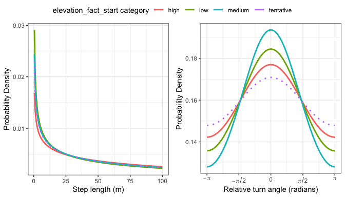

```r
# define the plot for step length distributions
sl_plot <- plot_updated_dist(
  updated_dist_params_obj = updated_param_sl_model1,
  print_plot = F,
  include_tentative = T,
  xlim = 100
)


# define the plot for turn angle distributions
# note that you need to supply the mean of the vonmises distribution
ta_plot <- plot_updated_dist(
  updated_dist_params_obj = updated_param_ta_model1,
  vonmises_mu = 0,
  print_plot = F,
  include_tentative = T
)

ggarrange(sl_plot, ta_plot, common.legend = T)
```

### Model 2: Continuous with Random Effects

#### Fitting the Model

We’ll fit our second ISSA with random effects and using our continuous variable, `elevation`. Our habitat selection variable is `elevation_end` and we interact the movement parameters with `elevation_start` per the way we paramerterized our first model. Unfortunately, this model doesn’t actually converge (due to the random effects), so in a non-example situation we would not want to use this model for inference, however it serves its purpose for this vignette. But note, we do not have SEs for our coefficients :(.

```r
model2 <- fit_model(
  data = fisher_data,
  model_name = "model_2",
  interaction_var_name = "elevation_start",
  habitat_selection_var_name = "elevation_end",
  include_random_effects = TRUE,
  save_model = TRUE
)

summary(model2)
```

```
#>  Family: poisson  ( log )
#> Formula:
#> case_ ~ sl_ + log_sl_ + cos(ta_) + elevation_end + elevation_start:sl_ +
#>     elevation_start:log_sl_ + elevation_start:cos(ta_) + (1 |
#>     step_id_) + (0 + sl_ + log_sl_ + cos(ta_) | id)
#> Data: data
#>
#>      AIC      BIC   logLik deviance df.resid
#>       NA       NA       NA       NA    17353
#>
#> Random effects:
#>
#> Conditional model:
#>  Groups   Name        Variance  Std.Dev.  Corr
#>  step_id_ (Intercept) 1.292e-09 3.594e-05
#>  id       sl_         1.131e-47 3.363e-24
#>           log_sl_     4.296e-25 6.554e-13 -0.77
#>           cos(ta_)    1.315e-01 3.626e-01  0.09 -0.71
#> Number of obs: 17368, groups:  step_id_, 684; id, 4
#>
#> Conditional model:
#>                            Estimate Std. Error z value Pr(>|z|)
#> (Intercept)              -3.301e+00         NA      NA       NA
#> sl_                       7.300e-04         NA      NA       NA
#> log_sl_                   1.065e-01         NA      NA       NA
#> cos(ta_)                 -2.496e-01         NA      NA       NA
#> elevation_end             9.686e-03         NA      NA       NA
#> sl_:elevation_start      -6.743e-06         NA      NA       NA
#> log_sl_:elevation_start  -1.223e-03         NA      NA       NA
#> cos(ta_):elevation_start -1.019e-04         NA      NA       NA
```

#### Update movement distribution parameters with random effects

Now use the model coefficients to once again update the movement parameters, this time including the random effects (e.g., individual movements).

```r
updated_param_sl_model2 <- mixedSSA::update_dist(
  model = model2,
  dist_name = "gamma",
  beta_sl = "sl_", # the name of the step length coefficient in our model
  beta_log_sl = "log_sl_", # the name of the log(step length) coefficient in our model
  interaction_var_name = "elevation_start", # elevation at the start of each step
  random_effects_var_name = "id", # must match the random effects in the model
  quantiles = c(0.05, 0.5, 0.95) # the quantiles for elevation for which we want to calculate the distribution parameters
)

# The updated params object contains a lot of attributes,
# but we'll just take a look at the updated params table with the random effects
updated_param_sl_model2@updated_parameters
```

```
#>     grouping random_effect  beta_sl beta_log_sl    shape    scale
#> 1  tentative          <NA>       NA          NA 0.625663 351.1637
#> 2       0.05            F1  2.7e-04    0.023054 0.648717 387.9599
#> 3       0.05            F2  2.7e-04    0.023054 0.648717 387.9599
#> 4       0.05            M1  2.7e-04    0.023054 0.648717 387.9599
#> 5       0.05            M4  2.7e-04    0.023054 0.648717 387.9599
#> 6       0.05       typical  2.7e-04    0.023054 0.648717 387.9599
#> 7        0.5            F1  6.5e-05   -0.014208 0.611455 359.3231
#> 8        0.5            F2  6.5e-05   -0.014208 0.611455 359.3231
#> 9        0.5            M1  6.5e-05   -0.014208 0.611455 359.3231
#> 10       0.5            M4  6.5e-05   -0.014208 0.611455 359.3231
#> 11       0.5       typical  6.5e-05   -0.014208 0.611455 359.3231
#> 12      0.95            F1 -1.0e-04   -0.044057 0.581606 339.2632
#> 13      0.95            F2 -1.0e-04   -0.044057 0.581606 339.2632
#> 14      0.95            M1 -1.0e-04   -0.044057 0.581606 339.2632
#> 15      0.95            M4 -1.0e-04   -0.044057 0.581606 339.2632
#> 16      0.95       typical -1.0e-04   -0.044057 0.581606 339.2632
```

```r
updated_param_ta_model2 <- mixedSSA::update_dist(
  model = model2,
  dist_name = "vonmises",
  beta_cos_ta = "cos(ta_)", # the name of the cos(ta) coefficient in our model
  interaction_var_name = "elevation_start",
  tentative_dist = tentative_ta_dist,
  random_effects_var_name = "id",
  quantiles = c(0.05, 0.5, 0.95)
)

# By default, the mu parameter of the vonmises distribution will be 0
updated_param_ta_model2@updated_parameters
```

```
#>     grouping random_effect beta_cos_ta     kappa mu
#> 1  tentative          <NA>          NA  0.072061  0
#> 2       0.05            F1   -0.752058 -0.679997  0
#> 3       0.05            F2   -0.005705  0.066355  0
#> 4       0.05            M1   -0.274568 -0.202508  0
#> 5       0.05            M4    0.006146  0.078206  0
#> 6       0.05       typical   -0.256546 -0.184486  0
#> 7        0.5            F1   -0.755163 -0.683103  0
#> 8        0.5            F2   -0.008810  0.063250  0
#> 9        0.5            M1   -0.277673 -0.205613  0
#> 10       0.5            M4    0.003040  0.075101  0
#> 11       0.5       typical   -0.259651 -0.187591  0
#> 12      0.95            F1   -0.757650 -0.685590  0
#> 13      0.95            F2   -0.011297  0.060763  0
#> 14      0.95            M1   -0.280160 -0.208100  0
#> 15      0.95            M4    0.000553  0.072614  0
#> 16      0.95       typical   -0.262139 -0.190078  0
```

#### Plot updated movement distributions

Again, we can use the package to plot the updated movement distributions, this time including the distributions for each individual.

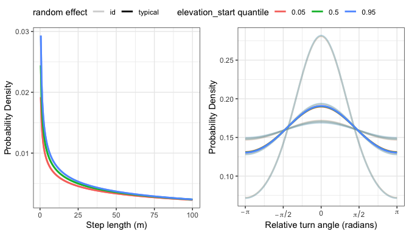

```r
# define the plot for step length distributions
sl_plot <- plot_updated_dist(
  updated_dist_params_obj = updated_param_sl_model2,
  print_plot = F,
  include_tentative = F, # this time don't include the tentative dist
  include_random_effect = T,
  xlim = 100
)


# define the plot for turn angle distributions
# note that you need to supply the mean of the vonmises distribution
ta_plot <- plot_updated_dist(
  updated_dist_params_obj = updated_param_ta_model2,
  vonmises_mu = 0,
  print_plot = F,
  include_tentative = F,
  include_random_effect = T
)

ggarrange(sl_plot, ta_plot, common.legend = T)
```